# Simple Data Analysis and Linear and Nonlinear Classification: The Red and White Wine datasets

We want to predict whether a given wine sample corresponds to a red or white wine.

The datasets are available in two separate csv files at https://www.kaggle.com/sgus1318/winedata

### Attribute Information:

Patterns have 12 numeric features.

1. fixed acidity
2. volatile acidity
3. citric acid
4. residual sugar
5. chlorides
6. free sulfur dioxide
7. total sulfur dioxide
8. density
9. pH
10. sulphates
11. alcohol
12. quality

To these we must add a 0-1 label where the positive class (1) corresponds to the smaller red wine sample.

### Instrucciones para la entrega final

**Seguid cuidadosamente las siguientes pautas:**

Para cualquier duda,consultar con el profesor (jose.dorronsoro@uam.es)

```python
%matplotlib inline
```

```python
#put all your imports here
import pandas as pd
import numpy as np
import matplotlib.pyplot as plt
import seaborn as sns
from sklearn.linear_model import LogisticRegression
from sklearn.metrics import roc_auc_score, scorer, f1_score, recall_score, precision_score, confusion_matrix
from sklearn.model_selection import GridSearchCV, cross_val_score, StratifiedKFold, train_test_split, cross_validate
from sklearn.pipeline import Pipeline
from sklearn.ensemble import RandomForestClassifier
from sklearn.preprocessing import StandardScaler, MinMaxScaler
from sklearn.neural_network import MLPClassifier
from sklearn.svm import SVC
from sklearn.decomposition import PCA
import matplotlib as mpl
from matplotlib.colors import ListedColormap
```

```python
def plot_confusion_matrix(y_true, y_pred, classes,
                          normalize=True,
                          title=None,
                          cmap=plt.cm.Greens):
    """
    This function prints and plots the confusion matrix.
    Normalization can be applied by setting `normalize=True`.
    """
    if not title:
        if normalize:
            title = 'Normalized confusion matrix'
        else:
            title = 'Confusion matrix, without normalization'

    # Compute confusion matrix
    cm = confusion_matrix(y_true, y_pred)
    # Only use the labels that appear in the data
    #classes = classes[unique_labels(y_true, y_pred)]
    if normalize:
        cm = cm.astype('float') / cm.sum(axis=1)[:, np.newaxis]
        print("Normalized confusion matrix")
    else:
        print('Confusion matrix, without normalization')

    print(cm)

    fig, ax = plt.subplots()
    im = ax.imshow(cm, interpolation='nearest', cmap=cmap)
    ax.figure.colorbar(im, ax=ax)
    # We want to show all ticks...
    ax.set(xticks=np.arange(cm.shape[1]),
           yticks=np.arange(cm.shape[0]),
           # ... and label them with the respective list entries
           xticklabels=classes, yticklabels=classes,
           title=title,
           ylabel='True label',
           xlabel='Predicted label')

    # Rotate the tick labels and set their alignment.
    plt.setp(ax.get_xticklabels(), rotation=45, ha="right",
             rotation_mode="anchor")

    # Loop over data dimensions and create text annotations.
    fmt = '.2f' if normalize else 'd'
    thresh = cm.max() / 2.
    for i in range(cm.shape[0]):
        for j in range(cm.shape[1]):
            ax.text(j, i, format(cm[i, j], fmt),
                    ha="center", va="center",
                    color="white" if cm[i, j] > thresh else "black")
    fig.tight_layout()
    return ax
```

## Loading Data

Previamente se han de juntar los dos csv de Kaggle en un único csv `wine.csv`que se cargará aquí a un dataframe.

```python
redwine = pd.read_csv('winequality_red.csv', encoding='utf-8')
redwine['label'] = [1]*redwine.shape[0]

whitewine = pd.read_csv('winequality_white.csv', encoding='utf-8')
whitewine['label'] = [0]*whitewine.shape[0]
```

```python
wine = pd.concat([redwine, whitewine])
```

Tendríamos que hacer shuffle sobre los datos para que no estén primero todas las observaciones de una de las dos clases y luego todas las observaciones de la otra clase; sin embargo, como vamos a hacer mucho cross validation y separaremos de manera aleatoria la muestra en train y test, esto no será preocupante, pues esta partición aleatoria ya asegurará que nuestro modelo verá las observaciones de las clases mezcladas. Lo hacemos de todas formas para asegurarnos; además así guardaremos la base de datos construida en un csv para que podamos cargar el mismo directamente la próxima vez que trabajemos con ello.

```python
wine = wine.sample(frac=1).reset_index(drop=True)
wine.to_csv('wine.csv')
```

## Data Exploration

Perform here descriptive statistics, boxplots and positive and negative class histograms

### Descriptive Statistics

and etc ...!!!

```python
wine.head()
```

|  | fixed acidity | volatile acidity | citric acid | residual sugar | chlorides | free sulfur dioxide | total sulfur dioxide | density | pH | sulphates | alcohol | quality | label |
| --- | --- | --- | --- | --- | --- | --- | --- | --- | --- | --- | --- | --- | --- |
| 0 | 6.3 | 0.17 | 0.23 | 5.7 | 0.048 | 44.0 | 147.0 | 0.99382 | 3.08 | 0.54 | 10.0 | 5 | 0 |
| 1 | 6.9 | 0.19 | 0.35 | 1.7 | 0.036 | 33.0 | 101.0 | 0.99315 | 3.21 | 0.54 | 10.8 | 7 | 0 |
| 2 | 8.6 | 0.23 | 0.25 | 11.3 | 0.031 | 13.0 | 96.0 | 0.99645 | 3.11 | 0.40 | 10.8 | 5 | 0 |
| 3 | 6.6 | 0.22 | 0.53 | 15.1 | 0.052 | 22.0 | 136.0 | 0.99860 | 2.94 | 0.35 | 9.4 | 5 | 0 |
| 4 | 8.2 | 0.33 | 0.39 | 2.5 | 0.074 | 29.0 | 48.0 | 0.99528 | 3.32 | 0.88 | 12.4 | 7 | 1 |

```python
wine.describe()
```

|  | fixed acidity | volatile acidity | citric acid | residual sugar | chlorides | free sulfur dioxide | total sulfur dioxide | density | pH | sulphates | alcohol | quality | label |
| --- | --- | --- | --- | --- | --- | --- | --- | --- | --- | --- | --- | --- | --- |
| count | 6497.000000 | 6497.000000 | 6497.000000 | 6497.000000 | 6497.000000 | 6497.000000 | 6497.000000 | 6497.000000 | 6497.000000 | 6497.000000 | 6497.000000 | 6497.000000 | 6497.000000 |
| mean | 7.215307 | 0.339666 | 0.318633 | 5.443235 | 0.056034 | 30.525319 | 115.744574 | 0.994697 | 3.218501 | 0.531268 | 10.491801 | 5.818378 | 0.246114 |
| std | 1.296434 | 0.164636 | 0.145318 | 4.757804 | 0.035034 | 17.749400 | 56.521855 | 0.002999 | 0.160787 | 0.148806 | 1.192712 | 0.873255 | 0.430779 |
| min | 3.800000 | 0.080000 | 0.000000 | 0.600000 | 0.009000 | 1.000000 | 6.000000 | 0.987110 | 2.720000 | 0.220000 | 8.000000 | 3.000000 | 0.000000 |
| 25% | 6.400000 | 0.230000 | 0.250000 | 1.800000 | 0.038000 | 17.000000 | 77.000000 | 0.992340 | 3.110000 | 0.430000 | 9.500000 | 5.000000 | 0.000000 |
| 50% | 7.000000 | 0.290000 | 0.310000 | 3.000000 | 0.047000 | 29.000000 | 118.000000 | 0.994890 | 3.210000 | 0.510000 | 10.300000 | 6.000000 | 0.000000 |
| 75% | 7.700000 | 0.400000 | 0.390000 | 8.100000 | 0.065000 | 41.000000 | 156.000000 | 0.996990 | 3.320000 | 0.600000 | 11.300000 | 6.000000 | 0.000000 |
| max | 15.900000 | 1.580000 | 1.660000 | 65.800000 | 0.611000 | 289.000000 | 440.000000 | 1.038980 | 4.010000 | 2.000000 | 14.900000 | 9.000000 | 1.000000 |

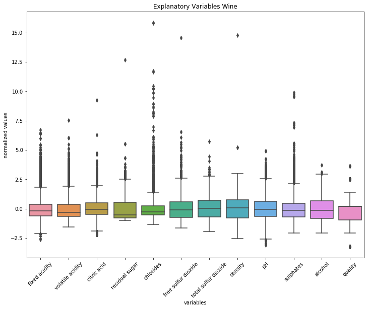

```python
plt.figure(figsize=(12, 9))
plt.title("Explanatory Variables Wine")
#sns.set_style("white")
bx_plot = sns.boxplot(data=(wine.drop('label', axis=1) - wine.drop('label', axis=1).mean()) / wine.drop('label', axis=1).std())
#bx_plot = sns.boxplot(data=df_housing)
plt.xticks(rotation=45)
plt.xlabel("variables")
plt.ylabel("normalized values")
plt.show()
```

Podemos observar que la mayoría de las variables tienen algunos valores atípicos. De hecho, no hay ninguna variable que no tenga ninguna observación fuera de los whiskers. Dibujamos ahora un pairplot, que son scatter plots entre las variables en los que se incluyen también histogramas. Para ver la relación que tiene cada par de variables sobre el label, ponemos la opción hue="label".

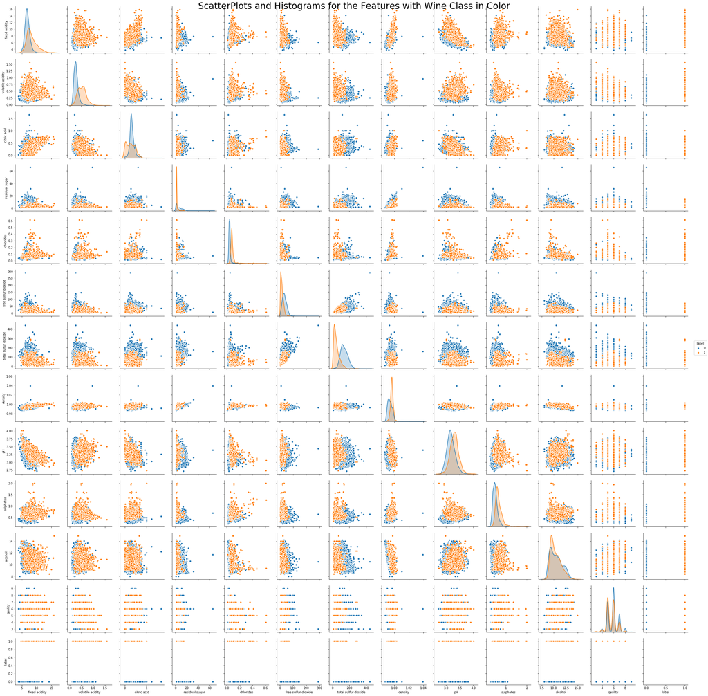

```python
PairPlot=sns.pairplot(wine, hue = "label", diag_kind="kde", diag_kws = dict(shade=True))
PairPlot.fig.suptitle('ScatterPlots and Histograms for the Features with Wine Class in Color', y=1., fontsize = 30)
plt.show()
```

```python
#dimensiones totales
wine.shape
```

```
(6497, 13)
```

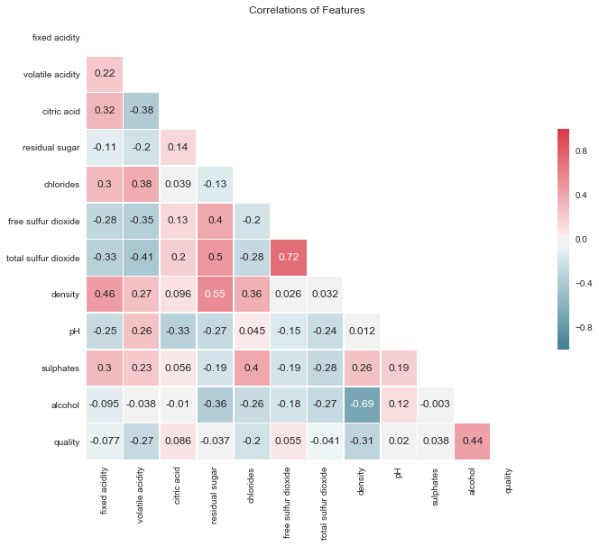

```python
sns.set(style="white")
'''
# Generate a large random dataset
rs = np.random.RandomState(33)
d = pd.DataFrame(data=rs.normal(size=(100, 26)),
                 columns=list(ascii_letters[26:]))
'''

target = wine['label']
features = wine.drop('label', axis = 1)

# Compute the correlation matrix
corr = features.corr()

# Generate a mask for the upper triangle
mask = np.zeros_like(corr, dtype=np.bool)
mask[np.triu_indices_from(mask)] = True

# Set up the matplotlib figure
f, ax = plt.subplots(figsize=(12, 9))

# Generate a custom diverging colormap
cmap = sns.diverging_palette(220, 10, as_cmap=True)
plt.title('Correlations of Features')
# Draw the heatmap with the mask and correct aspect ratio
sns.heatmap(corr, mask=mask, cmap=cmap,vmin=-1., vmax=1., center=0,
            square=True, linewidths=.5,
            annot=True, cbar_kws={"shrink": .5})
```

No observamos correlaciones demasiado significativas...La más alta de las negativas, es de -0.69, entre density y alcohol; en cuanto a las positivas, tenemos la esperada entre total sulfur dioxide y free sulfur dioxide; de 0.72.

[output not shown]

[output cut: 23 more lines]

[output not shown]

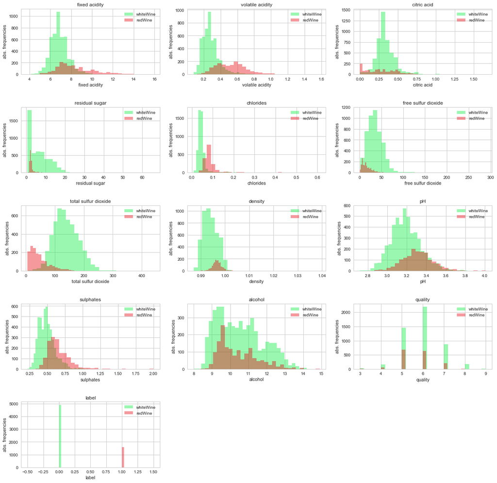

```python
sns.set_color_codes("bright")
sns.set_style("whitegrid")

num_columns = 3
num_rows = int(np.ceil(len(wine.columns)/num_columns ) )
bins = 30

plt.figure( figsize=(20, 4*num_rows))
plt.title("Red Wine vs. White Wine Histograms")


for i, var in enumerate (wine.columns):
    pos = np.where( wine['label'] == 1)[0]
    neg = np.where( wine['label'] == 0)[0]

    ax = plt.subplot(num_rows, num_columns, i+1)
    ax.set_title(var)
    #plt.hist( df_pima[ var ].iloc[pos], bins=bins, color='b', label='pos', alpha=0.5)
    #plt.hist( df_pima[ var ].iloc[neg], bins=bins, color='r', label='neg', alpha=0.5)

    sns.distplot( wine[ var ].iloc[neg], bins=bins, norm_hist=False, kde=False, color='g', label='whiteWine')
    sns.distplot( wine[ var ].iloc[pos], bins=bins, norm_hist=False, kde=False, color='r', label='redWine')

    plt.ylabel("abs. frequencies")
    plt.legend(loc='best')
plt.subplots_adjust(hspace=0.5)
plt.show()
```

En el caso de fixed acidity, podemos ver que los vinos tintos tienden a tener unos valores algo mayores en esta variable, aunque tenemos un error de Bayes alto (es decir, las clases están muy solapadas). En el caso de la volatile acidity este efecto es algo mayor y podríamos separar razonablemente bien las clases en base a su valor en esta variable. Es por tanto una buena candidata a ser eliminada, pues recordemos que eliminaremos las 5 variables que mayor impacto tendrán en la predicción, para dificultar más el problema. No ocurre lo mismo con citric acid, pues como vemos ambas clases están solapadas casi al completo, y un separador lineal no podría distinguir, en base a los valores de citric acid, la clase de vino que es. Podemos ver que el azúcar residual tiende a ser algo mayor en los vinos blancos, aunque hay vinos blancos con valores iguales a los que tiene el vino tinto en esta variable. Lo contrario sucede con chlorides, que tiene un error de Bayes bajo, y las clases quedan separadas en dos histogramas en los que sólo coinciden las colas. Parece que el vino tinto tiene más chlorides que el vino blanco, de forma general (tiende a tener más). Esta variable también es una buena candidata a ser eliminada. En el caso del free sulfur dioxide, aunque hay una tendencia general a que los vinos blancos tengan un valor mayor, el histograma de los vinos tintos queda incluido dentro del histograma de vinos blancos; no hay diferencias significativas por esta variable por tanto. Sin embargo, cuando se trata del *total* sulfur dioxide, sí podemos ver que los vinos tintos tienden a tener claramente unos valores menores en esta variable que los vinos blancos. Tanto la densidad como el PH parecen tener poco o nada que ver con que el vino sea tinto o blanco, pues los histogramas de ambas clases quedan solapados. En el caso de sulphates, aunque no se diferencian tan bien las clases como en otras variables que vimos anteriormente, sí se puede observar una cierta separación, y es que los vinos tintos parecen tender a tener más sulfatos que los vinos blancos. En términos de alcohol, como era de esperar, el error de Bayes es altísimo, pues como vemos no existe ninguna diferencia significativa en los grados de alcohol que tiene un vino en función de si es blanco o tinto. La calidad podríamos haberla tratado como una variable categórica, pero al estar ordenada decidimos tratarla como numérica (si no estuviera ordenada, es decir, si un 8 en calidad no indicara doble de calidad que un 4, tendría sentido pasarla a categórica). En esta variable se observan muy pocas diferencias, las cuales probablemente estén más relacionadas con el número de observaciones de cada clase que tenemos que con el tipo de vino. Esto último (desbalanceo de clases), puede verse en el último gráfico de barras, en el que vemos que la cantidad de vinos blancos de la muestra es bastante mayor a la cantidad de vinos tintos.

En un principio, vamos a eliminar las variables: fixed acidity, volatile acidity, chlorides, total sulfur dioxide y sulphates; pues estas son las variables que mayor relación parecen tener con nuestro "label", es decir la clase de vino.

### Simple Model Fitting

Explore here the application of a Logistic Regression Model.

```python
logreg = LogisticRegression(solver = 'lbfgs', random_state=69)
c = [10.**k for k in range(-10, 10)]
params_lr = {'C': c,
            'random_state': [69],
            'max_iter': [100, 500, 1000],
            'verbose':[1],
            'n_jobs':[-1]}

skfold = StratifiedKFold(5,
                      shuffle=True,
                        random_state=69)

searchLR = GridSearchCV(estimator=logreg,
                       param_grid=params_lr, scoring = scorer.make_scorer(roc_auc_score),
                       n_jobs=-1, verbose=1, cv = skfold)

X_train, X_test, y_train, y_test = train_test_split(features, target, test_size = 0.8, random_state=69)


_ = searchLR.fit(X_train, y_train)
```

```
Fitting 5 folds for each of 60 candidates, totalling 300 fits
```

```
[Parallel(n_jobs=-1)]: Using backend LokyBackend with 4 concurrent workers.
[Parallel(n_jobs=-1)]: Done  42 tasks      | elapsed:    4.6s
[Parallel(n_jobs=-1)]: Done 192 tasks      | elapsed:   12.2s
[Parallel(n_jobs=-1)]: Done 300 out of 300 | elapsed:   23.3s finished
[Parallel(n_jobs=-1)]: Using backend LokyBackend with 4 concurrent workers.
[Parallel(n_jobs=-1)]: Done   1 out of   1 | elapsed:    0.4s finished
```

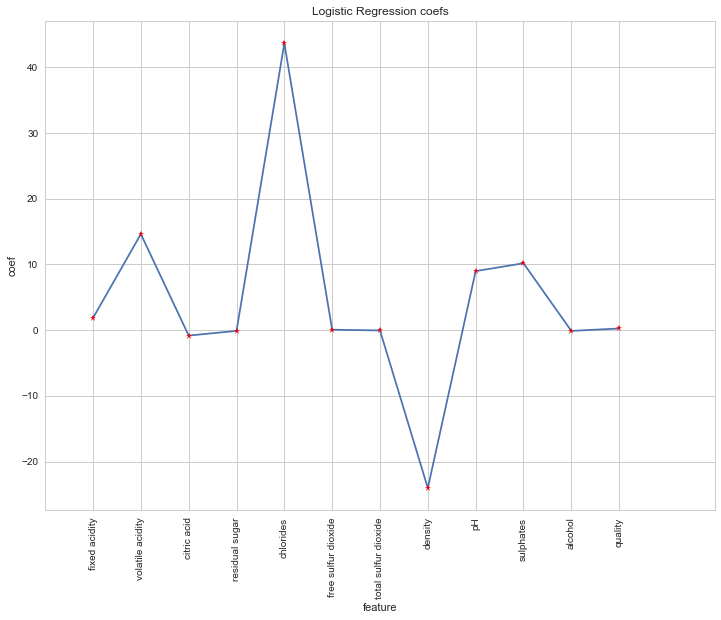

```python
nticks_coefs = len(wine.columns)-1

plt.rcParams['figure.figsize'] = (12, 9)

plt.title('Logistic Regression coefs')
plt.xlabel('feature')
plt.ylabel('coef')
plt.xlim(-1, nticks_coefs+1)
#plt.ylim(-1., 1.)
plt.xticks(range(nticks_coefs), features.columns, rotation='vertical')
_ = plt.plot(searchLR.best_estimator_.coef_.reshape( X_train.shape[1] ), '-', searchLR.best_estimator_.coef_.reshape( X_train.shape[1] ), 'r*')
```

Este gráfico sugiere que las variables más significativas para clasificar el vino como tinto o blanco son volatile acidity, chlorides, density, pH y sulphates. Los coeficientes para el resto de las variables son cercanos a 0.

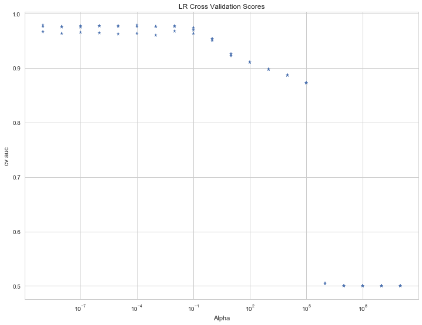

```python
lrDF = pd.DataFrame.from_dict(searchLR.cv_results_)

plt.title("LR Cross Validation Scores")
plt.xlabel('Alpha')
plt.ylabel('cv auc')
plt.xscale('log')
_ = plt.plot( 1./lrDF['param_C'], lrDF['mean_test_score'], '*')
plt.show()
```

```python
round(roc_auc_score(y_test, searchLR.best_estimator_.predict(X_test)), 3)
```

```
0.983
```

```python
round(f1_score(y_test, searchLR.best_estimator_.predict(X_test)), 3)
```

```
0.976
```

```python
round(recall_score(y_test, searchLR.best_estimator_.predict(X_test)), 3)
```

```
0.974
```

```python
round(precision_score(y_test, searchLR.best_estimator_.predict(X_test)), 3)
```

```
0.977
```

```
Normalized confusion matrix
[[0.99260015 0.00739985]
 [0.02580141 0.97419859]]
```

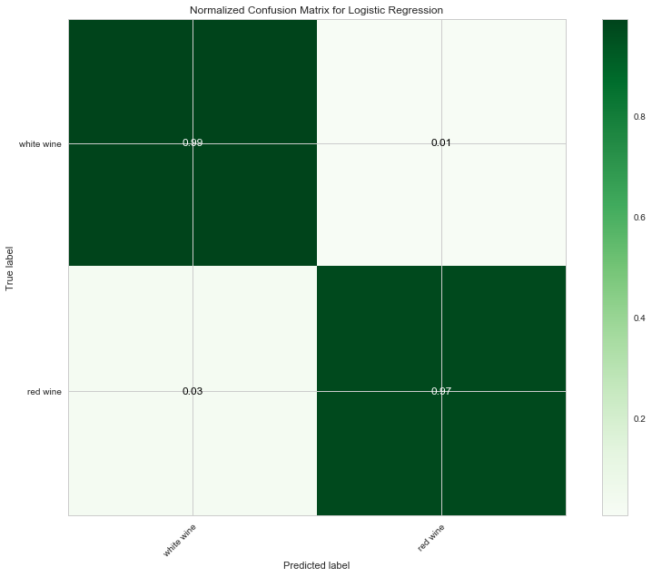

```python
plot_confusion_matrix(y_test, searchLR.best_estimator_.predict(X_test), classes=["white wine","red wine"], normalize=True, title="Normalized Confusion Matrix for Logistic Regression")
```